# Systolic Blood Pressure Analysis

Author

Rajin Panthee

**In this project, we analyze data from the Jackson Heart Study (JHS) to investigate the factors influencing systolic blood pressure (SBP).**

**0. Import the JHS data.**

```r
# Load the haven package to work with SAS data files
library(haven)
# Read the JHS data from the specified file path
jhs_data <- read_sas("C:\\Users\\rajpa\\Downloads\\analysis1.sas7bdat")
```

**1a. Model systolic blood pressure (*sbp*; mmHg) as a function of age (*age*; years), education (*HSgrad*; 0=no, 1=yes), and body mass index (*BMI*; kg/m<sup>2</sup>).**

```r
# Fit a generalized linear model with sbp as the dependent variable
# Predictors include age, HSgrad, and BMI
m1 <- glm(sbp ~ age + HSgrad + BMI, data = jhs_data, family = gaussian)
# Display a summary of the model
summary(m1)
```

```
Call:
glm(formula = sbp ~ age + HSgrad + BMI, family = gaussian, data = jhs_data)

Coefficients:
            Estimate Std. Error t value Pr(>|t|)
(Intercept) 95.04214    2.27546  41.768  < 2e-16 ***
age          0.44461    0.02544  17.480  < 2e-16 ***
HSgrad      -0.83780    0.85264  -0.983    0.326
BMI          0.23988    0.04087   5.870  4.9e-09 ***
---
Signif. codes:  0 '***' 0.001 '**' 0.01 '*' 0.05 '.' 0.1 ' ' 1

(Dispersion parameter for gaussian family taken to be 213.0267)

    Null deviance: 640015  on 2641  degrees of freedom
Residual deviance: 561964  on 2638  degrees of freedom
  (11 observations deleted due to missingness)
AIC: 21669

Number of Fisher Scoring iterations: 2
```

$$\begin{align*}
\hat{y} &= 95.04 + 0.44 \times \text{age} - 0.84 \times \text{HSgrad} + 0.24 \times \text{BMI}
\end{align*}$$

**1b. Construct the 95% confidence intervals for the regression coefficients.**

```r
# Calculate and display 95% confidence intervals for the model coefficients
confint(m1)
```

```
                 2.5 %     97.5 %
(Intercept) 90.5823244 99.5019635
age          0.3947597  0.4944632
HSgrad      -2.5089435  0.8333469
BMI          0.1597864  0.3199750
```

```r
# Load the dplyr package for data manipulation
library(dplyr)
# Select relevant columns and remove rows with missing values
data_new <- jhs_data %>%
  select(age, HSgrad, BMI, sbp) %>%
  na.omit()

# Compare the full model with the null model using an ANOVA test
suppressPackageStartupMessages({
  full <- glm(sbp ~ age + HSgrad + BMI, data = data_new, family = gaussian)
  reduced <- glm(sbp ~ 1, data = data_new, family = gaussian)
  anova(reduced, full, test = "F")
})
```

```
Analysis of Deviance Table

Model 1: sbp ~ 1
Model 2: sbp ~ age + HSgrad + BMI
  Resid. Df Resid. Dev Df Deviance      F    Pr(>F)
1      2641     640015
2      2638     561964  3    78051 122.13 < 2.2e-16 ***
---
Signif. codes:  0 '***' 0.001 '**' 0.01 '*' 0.05 '.' 0.1 ' ' 1
```

**1d. Identify significant predictors of systolic blood pressure.**

```r
# Display a summary of the model to identify significant predictors
summary(m1)
```

```
Call:
glm(formula = sbp ~ age + HSgrad + BMI, family = gaussian, data = jhs_data)

Coefficients:
            Estimate Std. Error t value Pr(>|t|)
(Intercept) 95.04214    2.27546  41.768  < 2e-16 ***
age          0.44461    0.02544  17.480  < 2e-16 ***
HSgrad      -0.83780    0.85264  -0.983    0.326
BMI          0.23988    0.04087   5.870  4.9e-09 ***
---
Signif. codes:  0 '***' 0.001 '**' 0.01 '*' 0.05 '.' 0.1 ' ' 1

(Dispersion parameter for gaussian family taken to be 213.0267)

    Null deviance: 640015  on 2641  degrees of freedom
Residual deviance: 561964  on 2638  degrees of freedom
  (11 observations deleted due to missingness)
AIC: 21669

Number of Fisher Scoring iterations: 2
```

**1e. Interpret the slopes of the predictors.**

The intercept represents the baseline systolic blood pressure when all predictors are zero. Age and BMI have positive coefficients, indicating an increase in SBP with higher age and BMI, while HSgrad has a negative but not statistically significant coefficient.

**1f. Visualize the model results.**

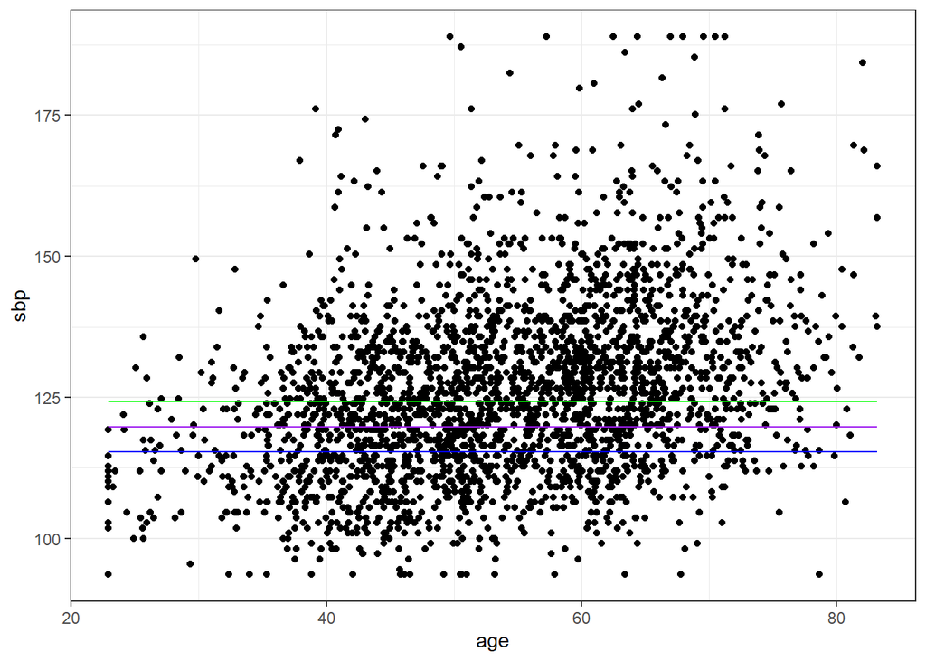

```r
# Load necessary packages for visualization
library(dplyr)
library(ggplot2)

# Extract coefficients from the model and calculate predicted SBP values for different ages
c1 <- coefficients(m1)
data_new <- jhs_data %>%
  select(age, HSgrad, BMI, sbp) %>%
  na.omit()

dataset <- data_new %>%
  mutate(sbp_hat_age30 = c1["(Intercept)"] + c1["age"]*30 + c1["HSgrad"]*mean(HSgrad) + c1["BMI"]*mean(BMI),
         sbp_hat_age40 = c1["(Intercept)"] + c1["age"]*40 + c1["HSgrad"]*mean(HSgrad) + c1["BMI"]*mean(BMI),
         sbp_hat_age50 = c1["(Intercept)"] + c1["age"]*50 + c1["HSgrad"]*mean(HSgrad) + c1["BMI"]*mean(BMI))

# Create a scatter plot of age vs SBP and overlay predicted lines for different ages
dataset %>%
  ggplot(aes(x = age)) +
  geom_point(aes(y = sbp)) +
  geom_line(aes(y = sbp_hat_age30), color = "blue") +
  geom_line(aes(y = sbp_hat_age40), color = "purple") +
  geom_line(aes(y = sbp_hat_age50), color = "green") +
  theme_bw()
```

**1g. Identify suspected outliers.**

```r
# Add a column to indicate suspected outliers based on standardized residuals
dataset <- data_new %>%
  mutate(outlier =  if_else(abs(rstandard(m1)) > 2.5, "Suspected", "Not Suspected"))
# Count the number of suspected outliers
outlier_count <- dataset %>% count(outlier)
print(outlier_count)
```

```
# A tibble: 2 × 2
  outlier           n
  <chr>         <int>
1 Not Suspected  2589
2 Suspected        53
```

**1h. Identify influential/leverage points.**

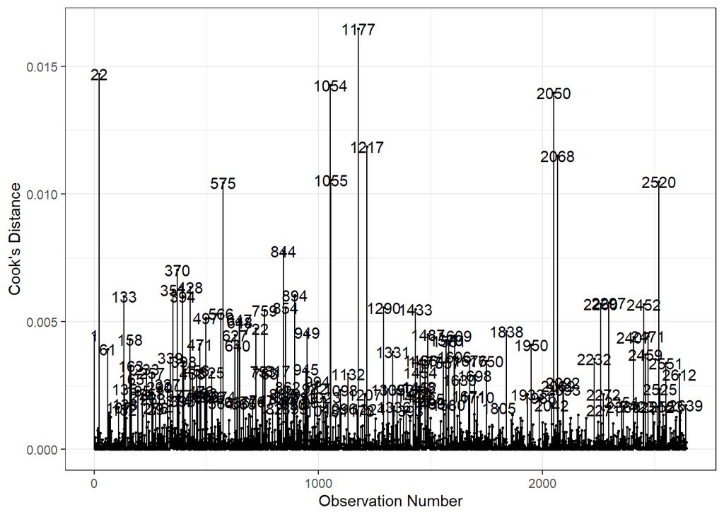

```r
# Use the cooks function from the classpackage to identify influential points
library(classpackage)
cooks(m1)
```

**1i. Assess multicollinearity in the model.**

```r
# Use the vif function from the car package to check for multicollinearity
car::vif(m1)
```

```
     age   HSgrad      BMI
1.102908 1.095671 1.007424
```

**2a. Model systolic blood pressure as a function of age, education, and health status (BMI categorized into three levels: poor, intermediate, ideal health).**

```r
# Load required packages
library(dplyr)
library(fastDummies)

# Select relevant columns and remove rows with missing values
jhs_data <-  jhs_data %>%
  select(age, HSgrad, BMI3cat, sbp) %>%
  na.omit()

# Create a new variable for health status based on BMI categories and generate dummy variables
jhs_data <-  jhs_data %>%
  mutate(health = case_when(BMI3cat == 0 ~ "poor_health",
                            BMI3cat == 1 ~ "intermediate_health",
                            BMI3cat == 2 ~ "ideal_health")) %>%
  dummy_cols(select_columns = c("health"))

# Display the first few rows of the modified dataset
head(jhs_data)
```

```
# A tibble: 6 × 8
    age HSgrad BMI3cat   sbp health   health_ideal_health health_intermediate_…¹
  <dbl>  <dbl>   <dbl> <dbl> <chr>                  <int>                  <int>
1  63.4      0       1  93.6 interme…                   0                      1
2  56.0      1       0 133.  poor_he…                   0                      0
3  56.5      1       1 120.  interme…                   0                      1
4  40.0      1       2 104.  ideal_h…                   1                      0
5  47.7      0       0 127.  poor_he…                   0                      0
6  68.1      0       0 136.  poor_he…                   0                      0
# ℹ abbreviated name: ¹health_intermediate_health
# ℹ 1 more variable: health_poor_health <int>
```

```r
# Fit a generalized linear model with sbp as the dependent variable and health as a predictor
m2 <- glm(sbp ~ age + HSgrad + health , data = jhs_data, family = gaussian)

# Display a summary of the model
summary(m2)
```

```
Call:
glm(formula = sbp ~ age + HSgrad + health, family = gaussian,
    data = jhs_data)

Coefficients:
                           Estimate Std. Error t value Pr(>|t|)
(Intercept)               101.21996    1.89423  53.436  < 2e-16 ***
age                         0.43573    0.02551  17.082  < 2e-16 ***
HSgrad                     -0.91572    0.85533  -1.071 0.284444
healthintermediate_health   0.96442    0.93298   1.034 0.301373
healthpoor_health           3.13837    0.87726   3.577 0.000353 ***
---
Signif. codes:  0 '***' 0.001 '**' 0.01 '*' 0.05 '.' 0.1 ' ' 1

(Dispersion parameter for gaussian family taken to be 214.3136)

    Null deviance: 640015  on 2641  degrees of freedom
Residual deviance: 565145  on 2637  degrees of freedom
AIC: 21685

Number of Fisher Scoring iterations: 2
```

$$\begin{align*}
\hat{y} &= 101.22 + 0.44 \times \text{age} - 0.92 \times \text{HSgrad} \\
&\quad + 0.96 \times \text{intermediate health} + 3.14 \times \text{poor health}
\end{align*}$$

**2b. Construct the 95% confidence intervals for the regression coefficients.**

```r
# Calculate and display 95% confidence intervals for the model coefficients
confint(m2)
```

```
                               2.5 %      97.5 %
(Intercept)               97.5073262 104.9325839
age                        0.3857329   0.4857248
HSgrad                    -2.5921343   0.7606933
healthintermediate_health -0.8641875   2.7930190
healthpoor_health          1.4189651   4.8577726
```

```r
# Display a summary of the model to identify significant predictors
summary(m2)
```

```
Call:
glm(formula = sbp ~ age + HSgrad + health, family = gaussian,
    data = jhs_data)

Coefficients:
                           Estimate Std. Error t value Pr(>|t|)
(Intercept)               101.21996    1.89423  53.436  < 2e-16 ***
age                         0.43573    0.02551  17.082  < 2e-16 ***
HSgrad                     -0.91572    0.85533  -1.071 0.284444
healthintermediate_health   0.96442    0.93298   1.034 0.301373
healthpoor_health           3.13837    0.87726   3.577 0.000353 ***
---
Signif. codes:  0 '***' 0.001 '**' 0.01 '*' 0.05 '.' 0.1 ' ' 1

(Dispersion parameter for gaussian family taken to be 214.3136)

    Null deviance: 640015  on 2641  degrees of freedom
Residual deviance: 565145  on 2637  degrees of freedom
AIC: 21685

Number of Fisher Scoring iterations: 2
```

**2d. Interpret the slopes of the predictors.**

The coefficients represent the impact of each predictor on SBP, with age being a significant predictor, while education and intermediate health are not. Poor health is associated with significantly higher SBP compared to ideal health.

**2e. Visualize the model results.**

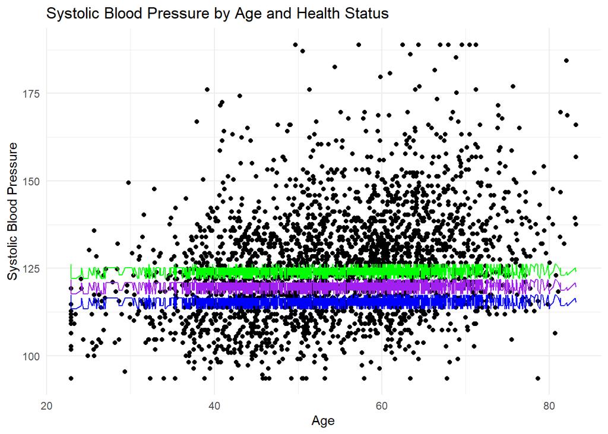

```r
# Calculate predicted SBP values for different health categories and ages
dataset <- jhs_data %>%
  mutate(
    sbp_hat_age30 = 101.21996 + 0.43573 * 30 - 0.91572 * HSgrad + 0.96442 * health_intermediate_health + 3.13837 * health_poor_health,
    sbp_hat_age40 = 101.21996 + 0.43573 * 40 - 0.91572 * HSgrad + 0.96442 * health_intermediate_health + 3.13837 * health_poor_health,
     sbp_hat_age50 = 101.21996 + 0.43573 * 50 - 0.91572 * HSgrad + 0.96442 * health_intermediate_health + 3.13837 * health_poor_health
  )

# Create a scatter plot of age vs SBP, adding smooth lines for predicted values for each age group
dataset %>%
  ggplot(aes(x = age)) +
  geom_point(aes(y = sbp)) +  # Scatter plot for actual SBP values
  geom_line(aes(y = sbp_hat_age30), color = "blue") +  # Line for predicted SBP at age 30
  geom_line(aes(y = sbp_hat_age40), color = "purple") +  # Line for predicted SBP at age 40
  geom_line(aes(y = sbp_hat_age50), color = "green") +  # Line for predicted SBP at age 50
  theme_minimal() +
  labs(title = "Systolic Blood Pressure by Age and Health Status",
       x = "Age",
       y = "Systolic Blood Pressure",
       color = "Predicted SBP")
```